# Project 2: Simulation

Xiangyi Wen; Tanner Huck

May 16th

```r
knitr::opts_chunk$set(echo = TRUE)
library(tidyverse)
library(BSDA)
```

## Part 1: Simulate to answer statistical questions

### Simulation 1

This first simulation is about finding the probability that at least one pair of two people share the same birthday. To do this we can simulate rooms of different amounts of people, assign them a random birthday, and check if anyone has the same birthday. For this simulation we will create rooms of 5,10,15,20,25,30,35,40,45,50 many people 1000 times each.

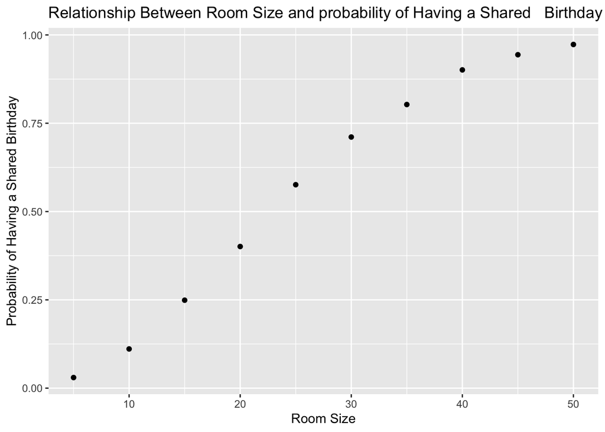

```r
# creating a variable for the number of replications we are testing for each room size
num_replications <- 1000
# creating a vector for the different room sizes
room_size <- c(5,10,15,20,25,30,35,40,45,50)

# creating a function that takes an input of the room size, and outputting a Boolean telling us if two people share a  birthday
test_birthday <- function(room_size) {
  test <- vector(length = room_size) # creating a vector of everyone in the room
  for (i in 1:room_size) {
    test[i] <- sample.int(365, 1) # Creating a random birthday for everyone in the room
  }
  return(!length(test) == length(unique(test))) # Testing if anyone has the same birthday as anyone else in the room
}

# make a matrix to hold data from your replications
replication <- matrix(nrow = num_replications, ncol = 10)
# run simulation
for (sizeIndex in 1:length(room_size)) {
  for (testNum in 1:num_replications) {
    replication[testNum, sizeIndex] <- test_birthday(room_size[sizeIndex])
  }
}

# make result vector that gives the proportion of shared birthdays for each value of the room size
result <- vector(length = length(room_size))
for (i in 1:length(room_size)) {
  result[i] <- mean(replication[,i])
}

# make dataframe for plotting that has a variable for sample size n and a variable for
# proportion of shared birthdays for that value of n
dataFrameResult <- data.frame(room_size,result)


# plot your results (as a well-labeled ggplot) to look at the relationship between room size and the probability of having a shared birthday
ggplot(dataFrameResult, aes(room_size, result)) +
  geom_point() +
  labs(title = "Relationship Between Room Size and probability of Having a Shared   Birthday",
       x = "Room Size", y = "Probability of Having a Shared Birthday")
```

From this simulation and graph, we learn that the room size does affect the probability of having a shared birthday. We can see that when the number of people in a room increases, then the probability of two people sharing a birthday also increases. This relationship appears to be mostly linear, with a slight curve at the end. This curve at the end shows that when the room is increasing from around 40 to 50 people, the increase in probability of having a shared birthday is smaller.

### Simulation 2

The second simulation is exploring the relationship between sample size and the probability of a type I error when testing hypothesis’. More specifically, when doing a two-sided t-test with null hypothesis that the population mean is equal to 1, and an alpha level of 0.05. We want to see what the probability is of type I error when doing this t-test with different sample sizes. To do this we will create a simulation with sample sizes of 10,20,30,40,50,60,70,80,90,100 under a normal and exponential distribution of mean 1 and variance 1. We will simulate each sample size 5000 times.

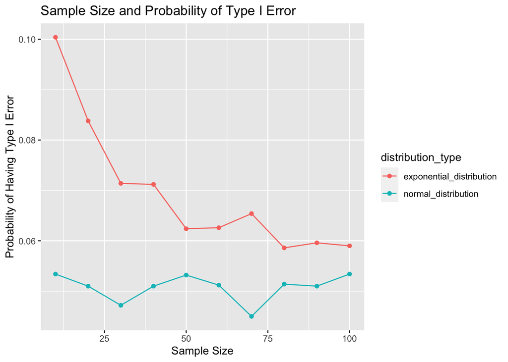

```r
# creating a vector for the different sample sizes
sample_size <- c(10,20,30,40,50,60,70,80,90,100)
# creating a variable for the number of replications we are testing for each sample size
num_replication <- 5000

# crating matrices to hold the data from the replications
# matrix for the normal distribution
replication_normal<- matrix(NA,nrow = num_replication,ncol = length(sample_size))
# Matrix for the exponential distribution
replication_expon<- matrix(NA,nrow = num_replication,ncol = length(sample_size))

# creating a function called test_error that will run the simulation for any sample size, it will creates a normal and exponential distribution for that sample size, creates a temporary matrix called result to hold the results, runs a t-test with the distributions and saves the p-value to the result matrix
# inputs: any sample size, creates a normal and exponential distribution for that
# outputs: returns the result matrix
test_error <- function(sample_size) {
  # creating normal and exponential distributions
  data_normal <- rnorm(sample_size, mean = 1)
  data_expon <- rexp(sample_size, rate = 1)
  # creating matrix called result for the p-values
  result <- matrix(NA,1,2)
  # calculating p-values and testing if they are less than the alpha level, which will return a Boolean true of false. (meaning that there is type I error if the Boolean is   true) then saving it to the result matrix for each distribution
  result[1] <- t.test(data_normal, alternative = "two.sided", mu = 1)$p.value < 0.05
  result[2] <- t.test(data_expon, alternative = "two.sided", mu = 1)$p.value < 0.05
  # returns the result matrix
  return(result)
}

# using a for loop to run the simulation 5000 times and save the results into two larger matrices, one for each type of distribution
for (sizeIndex in 1:length(sample_size)) { # will run for each sample size
  for (testNum in 1:num_replication) { # will run 5000 times
    # uses the test_error function to get the p-values for normal and exponential distributions
    value <- test_error(sample_size[sizeIndex])
    # saves the p-value for the normal distribution to the matrix replication_normal
    replication_normal[testNum, sizeIndex] <- value[1]
    # saves the p-value for the exponential distribution to the matrix replication_expon
    replication_expon[testNum, sizeIndex] <- value[2]
  }
}

# creating a matrix to hold the final results
result <- matrix(NA, nrow = 2, ncol = length(sample_size))
# for loop to run through each sample size
for (i in 1:length(sample_size)) {
  # calculating the probability of having a type I error for each distribution
  result[1,i] <- mean(replication_normal[,i])
  result[2,i] <- mean(replication_expon[,i])
}

# creating a graph of our results
dataFrameResult <- data.frame(rep(sample_size, 2), c(result[1,], result[2,]), c(rep("normal_distribution", 10), rep("exponential_distribution", 10)))
colnames(dataFrameResult) <- c("sample_size", "probability","distribution_type")
ggplot(dataFrameResult, aes(sample_size, probability, group = distribution_type, color = distribution_type)) +
  geom_point() +
  geom_line() +
  labs(title = "Sample Size and Probability of Type I Error",
       x = "Sample Size", y = "Probability of Having Type I Error")
```

Type I error when hypothesis testing is when you get a false positive. Or in other words, it is when the null hypothesis is true, but you chose to reject it. In our case the null hypothesis is that the population mean is equal to 1. Type I error occurs when we reject the null hypothesis, given that the null hypothesis is true, meaning that the true population mean is equal to 1. When we look at our simulation results, we can see the probability for this error for a normal distribution and exponential distribution with different sample sizes. We can see that for normal distributions, the probability of having this error is low, regardless of the sample size. For exponential distributions, the larger the sample size, the less likely you are to get type I error.

### Simulation 3

For this simulation we are looking at the relationship between the effect size (the magnitude of β) and the power of a t-test for a coefficient in a linear model. We want to consider different effect sizes for β, and how that will effect each response Y from a linear model. We will simulate each size of beta 1000 times.

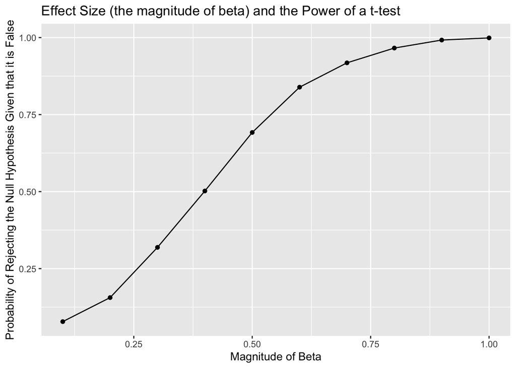

```r
# creating the X vector to use later on to generate each response Y
set.seed(302)
X <- rbinom(100, size = 1, prob = 0.5)
# creating the effect sizes for β in a vector
beta <- c(0.1,0.2,0.3,0.4,0.5,0.6,0.7,0.8,0.9,1)

# creating a function called test_power that will take any given beta value and the X vector and calculate each response Y.
# inputs: beta value and the X vector
# outputs: a Boolean value related to if you reject the null hypothesis
test_power <- function(beta, X) {
  epsilon <- rnorm(100,0,1) # generating 100 values from a normal distribution
  Y <- 5 + X*beta + epsilon # calculating the Y value
  df <- data.frame(X,Y)
  result <- my_lm(X~Y,df) # testing to see if we reject the null hypothesis
  return(result)
}

# creating a function called my_lm (same as in lab 3) that will take a formula and data to test if we reject the null hypothesis
# inputs: a formula of the linear model, and the data frame
# outputs: a Boolean value related to if you reject the null hypothesis
my_lm <- function(formula, data) {
  X <- model.matrix(formula, data)
  Y <- model.response(model.frame(formula, data))
  lrCoe <- solve( t(X) %*% X ) %*% t(X) %*% Y
  df <- nrow(data) - 2 # calculates degrees of freedom
  sigma_sq <- sum(((Y - X %*% lrCoe) ^2) / df)
  error_lrCoe <- sqrt(diag(sigma_sq * (solve(t(X) %*% X)))) # calculates standard error
  t_value <- lrCoe / error_lrCoe # calculates the t-statistic
  p_value <- 2 * pt(abs(t_value), df, lower.tail = FALSE) # calculates the p-value
  return(p_value[2] < 0.05)
}

# creating a variable for the number of replications we are testing for each beta
num_replication <- 1000
# creating a matrix to hold the results
replication <- matrix(nrow = num_replication, ncol = length(beta))

# Using a for loop that will run the simulation for each beta value and number of replications and saves it to a matrix replication
for (sizeIndex in 1:length(beta)) {
  for (testNum in 1:num_replication) {
    replication[testNum, sizeIndex] <- test_power(beta[sizeIndex], X)
  }
}

# creating a matrix to hold the final results
result <- vector(length = length(beta))
# for loop to run through each beta value
for (i in 1:length(beta)) {
  # calculating the probability of rejecting the null hypothesis
  result[i] <- mean(replication[,i])
}

# creating a graph of our results
dataFrameResult <- data.frame(beta,result)
ggplot(dataFrameResult, aes(beta, result)) +
  geom_point() +
  geom_line() +
  labs(title = "Effect Size (the magnitude of beta) and the Power of a t-test",
       x = "Magnitude of Beta", y = "Probability of Rejecting the Null Hypothesis Given that it is False")
```

Power is the probability of rejecting the null hypothesis given that it is false. In our linear model, the null hypothesis is that beta is equal to zero. However, we are generating data where the beta value will never be zero. This means that the null hypothesis will always be false, meaning that all we need to find is the probability of rejecting the null hypothesis. From our results, we can see that when the magnitude of beta increases, than the probability of rejecting the null also increases. We can see that when the magnitude of beta reaches 1, then the probability of rejecting the null hypothesis approaches 100%. This also shows us that when the magnitude of beta increases then the power also increases.

## Part 2: Simulate to Teach

### Simulation 4

One statistical topic that we found interesting was the probability of a certain event. One specific event we were curious about was the probability of winning the lottery. It seems like everyone always tells you not to play the lottery and that you never win any money, but we wanted to see what the probability of winning actually is.

To find the probability of winning the jackpot, we can first calculate this mathematically. Since there are 59 white balls, the probability of guessing the first white ball right is 1/59. Then out of the remaining 58 balls, the probability of guessing the second white ball right is 1/58. Following this pattern, the probability of guessing 5 white balls correctly would be $(1/59) * (1/58) * (1/57) * (1/56) * (1/55)$, or about a $1.665e-7$ percent chance. Then, we also have to guess the red ball correctly, which is a 1/42 chance, meaning the final probability of winning the jackpot would be a $1.665e-9 * (1/42)$ or a $3.963e-9$ percent chance.

Another way to find this probability, would be to run a simulation. We chose to run a simulation of 1000 people playing the power ball lottery 2000 times with 1000 times of normal play and 1000 times of power play. If you play the normal power ball lottery 1000 times, it will cost you 1000 dollars and 2000 dollars to play power play 1000 times.

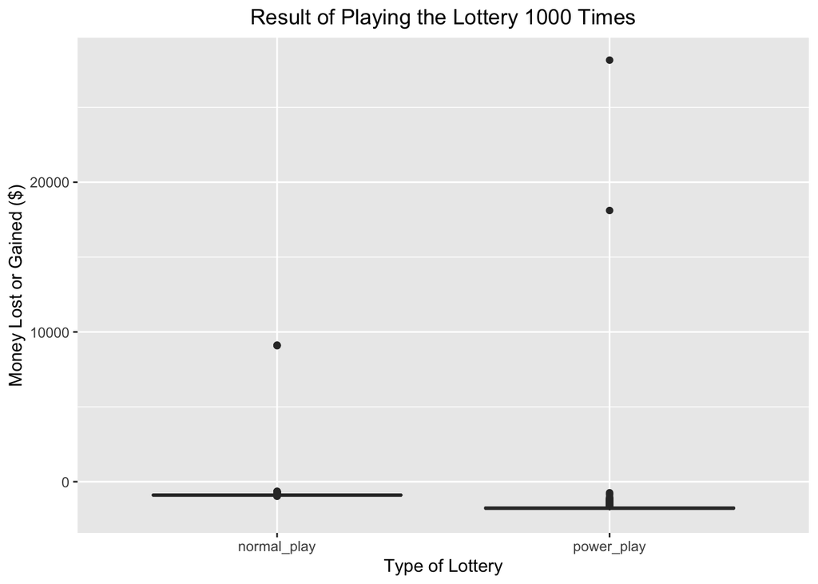

```r
# creating the winning numbers for the white and red loto
Jackpot_white <- sample.int(59,5)
Jackpot_red <- sample.int(42,1)

# creating a function called buyOne that will play the loto one time
# inputs: the winning numbers for each loto and if they are doing power play
# outputs: the total amount gained or lost from a single play
buyOne <- function(Jackpot_white, Jackpot_red, powerplay) {
  # an if to see if this is a power play
  if (powerplay){
    prize <- -2 # will cost 2 dollars if a power play
  } else {
    prize <- -1 # will cost 1 dollar if a regular play
  }
  # creating the numbers that the person chooses
  white_ball <- sample.int(59,5)
  power_ball <- sample.int(42,1)
  # Checking to see if the person chose the winning numbers
  whiteMatch <- length(unique(c(white_ball, Jackpot_white[1:5])))
  redMatch <- power_ball == Jackpot_red
  # if they chose the red ball and any white balls correctly, diciding how much they will win
  if (redMatch) {
    if (whiteMatch == 10) {
      prize <- prize + 3
    } else if (whiteMatch == 9) {
      prize <- prize + 4
    } else if (whiteMatch == 8) {
      prize <- prize + 7
    } else if (whiteMatch == 7) {
      prize <- prize + 100
    } else if (whiteMatch == 6) {
      prize <- prize + 10000
    } else {
      return(prize + 10000000)
    }
  } else { # if they did not get the red ball correctly
    if (whiteMatch == 7) {
      prize <- prize + 7
    } else if (whiteMatch == 6) {
      prize <- prize + 100
    } else if (whiteMatch == 5) {
      prize <- prize + 200000
    }
  }
  # if it was a power play, they get a bonus
  if (powerplay && prize != -2){
    return(prize*(sample.int(4,1)+1))
  }
  # return how much money they made or lost in a single play
  return(prize)
}

# creating variables for the total number of people and how many times they will play the lottery for the simulation
populationNum <- 1000
totalTicket <- 1000

# creating a matrix to hold the results from the simulation
money_lost <- matrix(NA,2*populationNum,2)


# Using a for loop that will run the simulation for all the people and all the plays, then saving the results to the money_lost matrix
for (i in 1:populationNum) {
  money_normal <- 0
  money_power <- 0
  for (ticketNum in 1:totalTicket) { # usuing the buyOne function to run the simulation
    money_normal <- money_normal + buyOne(Jackpot_white, Jackpot_red, FALSE)
    money_power <- money_power + buyOne(Jackpot_white, Jackpot_red, TRUE)
  }
  index <- i*2-1
  money_lost[index, 1] <- money_normal
  money_lost[index, 2] <- "normal_play"
  money_lost[index+1, 1] <- money_power
  money_lost[index+1, 2] <- "power_play"
}

# putting the results into a box plot
dataFrameResult <- data.frame(money_lost)
colnames(dataFrameResult) <- c("money_lost", "play_type")
dataFrameResult$play_type <- as.factor(dataFrameResult$play_type)
dataFrameResult$money_lost <- as.numeric(dataFrameResult$money_lost)
ggplot(dataFrameResult, aes(x = play_type, y = money_lost)) +
  geom_boxplot() +
  labs(title = "Result of Playing the Lottery 1000 Times",
   x = "Type of Lottery", y = "Money Lost or Gained ($)") +
  theme(plot.title = element_text(hjust = 0.5))
```

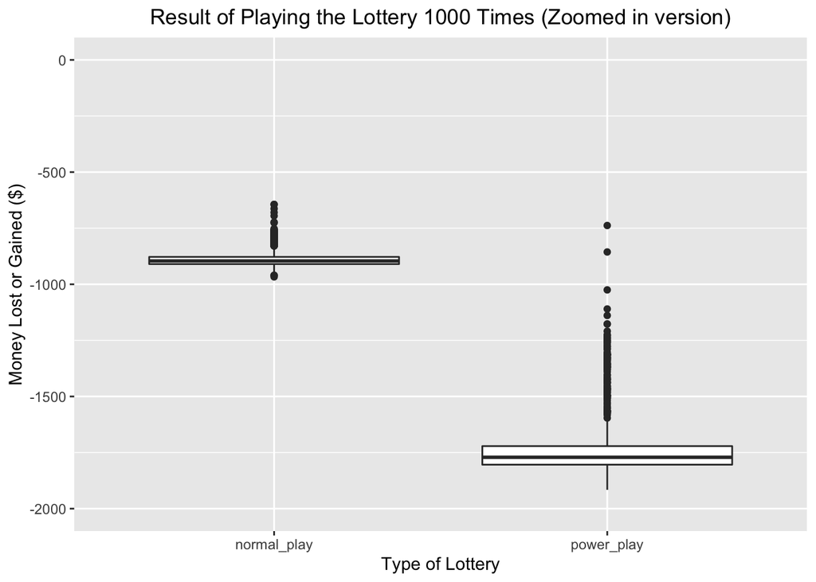

```r
# creating another box plot that is zoomed in more
ggplot(dataFrameResult, aes(x = play_type, y = money_lost)) +
  geom_boxplot() +
  labs(title = "Result of Playing the Lottery 1000 Times (Zoomed in version)",
   x = "Type of Lottery", y = "Money Lost or Gained ($)") +
  theme(plot.title = element_text(hjust = 0.5)) +
  ylim(-2000,0)
```

In our simulation for each ticket, to simulate the process of choosing the lottery jackpot, we will first generate 5 random numbers from 1:59 for the white balls and 1 random number from 1:42 for the red ball. We will simulate the process of buying the ticket by setting the starting money to be -1 or -2 based on the type of play. Then we simulate choosing balls by again generating 5 random numbers from 1:59, and 1 random number from 1:42. Finally we will compare the numbers we got in this single simulation with the jackpot numbers to see if we gain or lose any money. By running this simulation multiple times, we are able to simulate 1000 people buying 2000 tickets (1000 normal play and 1000 power play) each. And we will visualize the result of their lost or gain after buying those tickets.

After running our simulation and graphing our results, you can see that majority of people that played the lottery lost money. After spending the 1000 or 2000 dollars to play 1000 times, all but a few people did not break even. In playing the normal power ball lottery 1000 times, most people lost more than 750 dollars and in playing the power play lottery, most people lost more that 1500 dollars. If you run the simulation over and over again, you might see someone win thousands of dollars, but it is very rare.

When we look back at the probability we solved mathematically, this supports the results we found in the simulation. After running the simulation 1000 times, we can see that it is possible to win money, but it is very unlikely. Because we see a very little amount of people making money, the probability we solved mathematically makes sense. In our simulation of $2,000,000$ ($1000 * 2000$) total tickets, no one won the jackpot.

We conclude that the probability of winning the lottery is very small, you are much more likely to lose money than make money when playing power ball lottery. Our recommendation is that you do not play the power ball lottery, maybe invest the money instead.